**Title**: Anomalous latitudinal gradients in parasitoid wasp diversity - hotspots in regions with larger temperature range.

Jessica Castellanos-Labarcena<sup>1</sup>*, Dirk Steinke<sup>1,2</sup>, Sarah J. Adamowicz1^

1. Department of Integrative Biology, University of Guelph, Guelph, Ontario, Canada
2. Centre for Biodiversity Genomics, University of Guelph, Guelph, Ontario, Canada

*Corresponding Author

email: jcaste01@uoguelph.ca (JCL)

**Author Contributions:** JCL and SJA conceived the idea; JCL obtained and analyzed the data with assistance from SJA and DS; JCL led the writing with assistance from DS and SJA.

**Data Availability:** The data and code that support the findings of this study are openly available on GitHub at https://github.com/Labarcena-Jessica/Assignment-Reproducibility.

**Conflict of Interest statement**

No conflicts of interest

**Acknowledgements:** I would like to thank the instructors and all member of the Data Living Project for this excellent course.

# Abstract

# Introduction

The emergence of comprehensive global datasets of the spatial distribution of species, as well as molecular and fossil record information, has facilitated global analyses of diversity gradients. However, most studies testing the latitudinal diversity gradient (LDG) have focused on vertebrates and woody plants, as those are the taxa with the most data available. A lack of data for most invertebrate groups has limited the number of analyses, although several pioneering studies have examined the LDG in insects [Condamine et al. (2012)](Owen and Owen, 1974).

The most notable pattern observed is the one of species richness increasing from the poles to the equator (Saupe et al., 2019). However, some groups, e.g., ichneumonid wasps, show an anomalous latitudinal diversity gradient, which is characterized by higher diversity in some temperate regions compared to tropical biomes (Owen and Owen, 1974). These parasitoid wasps (Ichneumonoidea: Ichneumonidae, Braconidae and the recently described Trachypetidae family (Quicke et al., 2020) constitute a large and ecologically important group within the Hymenoptera, with approximately 41,000 described species, likely representing just a fraction of its true diversity. Ichneumonids play a key role in regulating populations of many groups of insects, including pests that affect agriculture, horticulture, and forestry. However, in particular, the tropical diversity of ichneumonoids is still poorly understood, as most sampling and species-level taxonomic descriptions have been focusing on temperate regions. Several studies highlight that the understanding of large-scale diversity patterns in these families is hindered by inadequate sampling of tropical species (Quicke, 2012).

Yet, this scenario is changing as large-scale studies are being conducted in Southeast Asia , South America, Uganda, and South Africa; revealing and characterizing the vast diversity of southern parasitoid wasps. Additionally, a new research program in Costa Rica aims to conduct a comprehensive, nationwide Malaise trapping program to barcode the nation’s multicellular biodiversity. Nevertheless, based on current knowledge, these families show strong latitudinal patterns of species richness peaking at temperate latitudes and declining near the equator (Quicke, 2014).

This study used a macrogenetics approach to explore large-scale patterns and predictors of intraspecific genetic diversity in parasitoid wasps. To account for the taxonomic debt at lower latitudes, (Freeman and Pennell, 2021) we used molecular clusters as a proxy for species, as in this highly diverse and less-studied group, a high number of cryptic species can be expected (Smith et al., 2008). With very limited taxonomic expertise available worldwide, the use of DNA-based clustering of specimens into species has shown to be a low-cost and low-risk methodology in most taxa, especially in insects (Cariou et al., 2020). This approach constitutes an area of active debate, so we implemented several quality control steps to account for taxonomic misclassification, contaminations, and sequencing errors within each molecular cluster. We used a publicly available genetic dataset for the DNA barcoding region cytochrome C oxidase subunit I (COI). Mitochondrial loci have long been used for exploring correlations between species and genetic diversity in global-scale macrogenetic studies, and despite the limitations associated with using a single gene, this is likely the best way to conduct large-scale biodiversity studies of largely unexplored taxonomic groups.

We also explored the effect of sampling coverage to determine the minimum number of sequences needed to calculate accurate intraspecific diversity estimates. The data were grouped at three different geographic scales to account for the fact that the geographic distance between pairs of conspecific sequences influences the expected genetic diversity in a set of DNA sequences. Therefore, we used grid cells, latitudinal bands, and climatic zones to explore global patterns of intraspecific genetic diversity. We examined the spatial relationship between intra- and interspecific levels of diversity and explored environmental predictor variables influencing the anomalous diversity pattern reported for this group.

# Methods

**Data Acquisition, filtering, and quality control**.

We downloaded the data directly into R (R Core Team, 2023) using the Barcode Of Life Data System (BOLD) (Ratnasingham and Hebert, 2013) API (Application-Platform Interface) on October 19, 2021. The combined data set for Ichneumonidae and Braconidae consisted of 243,870 sequences of the 5’ region of the cytochrome c oxidase subunit I gene (*COI*-5P), the barcode gene for animals.

**Intraspecific diversity estimation**

We calculated the nucleotide diversity per molecular cluster after grouping the data into three different spatial resolution levels: hexagonal grid cells, latitudinal bands, and climatic zones. We used the R package dggridR (version 3.00) (Barnes and Sahr, 2017) to build a global grid of hexagonal cells of 209,904 km<sup>2</sup>, all of which with identical sizes. The data were grouped by cells using the geographic coordinates associated with each record. We aligned the sequences of each molecular cluster in each cell using the R package muscle. The nucleotide diversity (Π) was calculated as the average number of variable sites in each pairwise sequence comparison using the R package PopGenome (verison 2.7.5) (Pfeifer et al., 2014). Average pairwise nucleotide differences (using Nei’s calculation of pi were divided by the number of base pairs to obtain diversity per site values. The function used, diversity.Stats, incorporates the calculated number of comparisons per site, which results in a Π value weighted by the number of comparisons. The average genetic diversity per cell was calculated as the mean of all nucleotide diversity values per molecular cluster in each cell. Considering that the intensity of sampling, both in terms of the number of molecular clusters per cell and the number of sequences in each molecular cluster, varied substantially among cells, we also evaluated the impact of this variation. Molecular clusters with 10 or more sequences were used for sensitivity tests following (Miraldo Andreia et al., 2016). These clusters and only cells with three or more molecular clusters were retained for further analysis. We mapped the nucleotide diversity values per cell using the R package tmap (version 3.3-3).

# Results

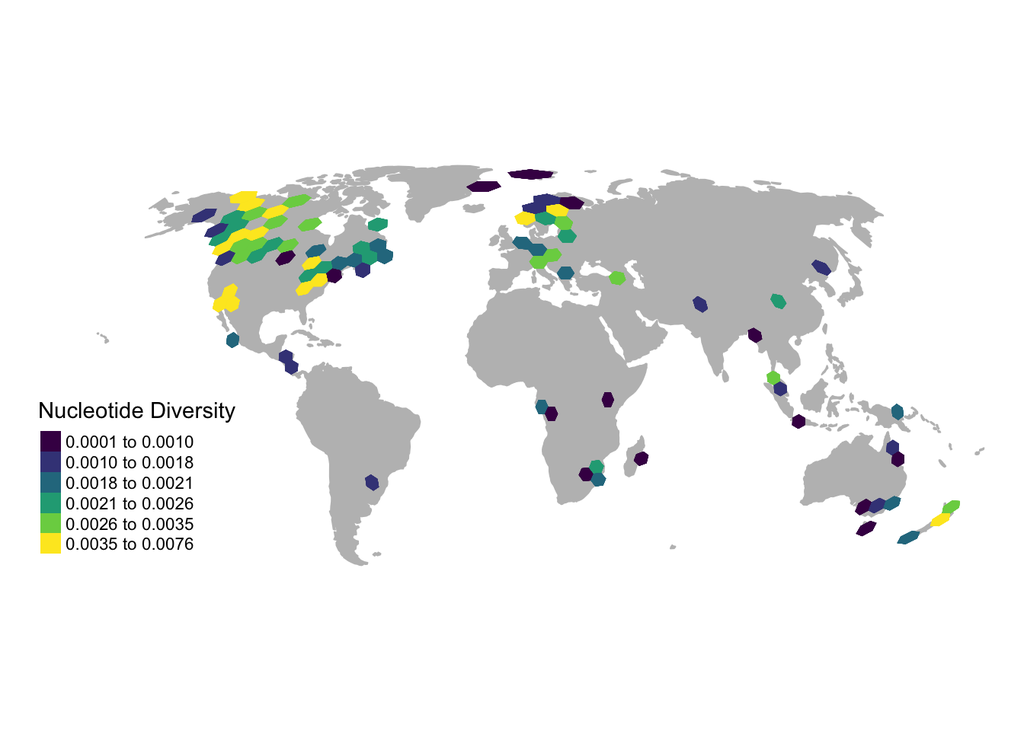

Figure 1: Global patterns of nucleotide diversity for parasitoid wasps. (a) Hexagonal grid cells of approximately 209,904 km2 show the mean nucleotide diversity values in a colour gradient where yellow represents higher values. Using a dataset of 209,382 COI records grouped in 15,584 molecular clusters, nucleotide diversity (Π) per molecular cluster was calculated as the average number of variable sites in each pairwise sequence comparison. After filtering, 85 cells were retained for a minimum of three molecular clusters per cell and 10 COI sequences per molecular cluster.

# Discussion

# References

Barnes, Sahr, 2017. dggridR: Discrete global grids for r. R package version 2.0.4. https://doi.org/10.5281/zenodo.1322866

Cariou, M., Henri, H., Martinez, S., Duret, L., Charlat, S., 2020. How consistent is RAD-seq divergence with DNA-barcode based clustering in insects? Molecular Ecology Resources 20, 1294–1298. https://doi.org/10.1111/1755-0998.13178

Condamine, F.L., Sperling, F.A.H., Wahlberg, N., Rasplus, J.-Y., Kergoat, G.J., 2012. What causes latitudinal gradients in species diversity? Evolutionary processes and ecological constraints on swallowtail biodiversity. Ecology Letters 15, 267–277. https://doi.org/10.1111/j.1461-0248.2011.01737.x

Freeman, B.G., Pennell, M.W., 2021. The latitudinal taxonomy gradient. Trends in Ecology & Evolution 36, 778–786. https://doi.org/10.1016/j.tree.2021.05.003

Lawrence, E.R., Pedersen, E.J., Fraser, D.J., n.d. Macrogenetics reveals multifaceted influences of environmental variation on vertebrate population genetic diversity across the Americas. Molecular Ecology n/a. https://doi.org/10.1111/mec.17059

Miraldo Andreia, Li Sen, Borregaard Michael K., Flórez-Rodríguez Alexander, Gopalakrishnan Shyam, Rizvanovic Mirnesa, Wang Zhiheng, Rahbek Carsten, Marske Katharine A., Nogués-Bravo David, 2016. An anthropocene map of genetic diversity. Science 353, 1532–1535. https://doi.org/10.1126/science.aaf4381

Owen, D.F., Owen, J., 1974. Species diversity in temperate and tropical Ichneumonidae. Nature 249, 583–584. https://doi.org/10.1038/249583a0

Pfeifer, B., Wittelsbürger, U., Ramos-Onsins, S.E., Lercher, M.J., 2014. PopGenome: An efficient swiss army knife for population genomic analyses in r. Molecular Biology and Evolution 31, 1929–1936. https://doi.org/10.1093/molbev/msu136

Quicke, D.L.J., 2014. Local and Global Patterns in Diversity. John Wiley & Sons, Ltd, pp. 489–512. https://doi.org/10.1002/9781118907085.ch15

Quicke, D.L.J., 2012. We Know Too Little about Parasitoid Wasp Distributions to Draw Any Conclusions about Latitudinal Trends in Species Richness, Body Size and Biology. PLOS ONE 7, e32101. https://doi.org/10.1371/journal.pone.0032101

Quicke, D.L.J., Austin, A.D., Fagan-Jeffries, E.P., Hebert, P.D.N., Butcher, B.A., 2020. Molecular phylogeny places the enigmatic subfamily Masoninae within the Ichneumonidae, not the Braconidae. Zoologica Scripta 49, 64–71. https://doi.org/10.1111/zsc.12390

Ratnasingham, S., Hebert, P.D.N., 2013. A DNA-Based Registry for All Animal Species: The Barcode Index Number (BIN) System. PLOS ONE 8, e66213. https://doi.org/10.1371/journal.pone.0066213

Saupe, E.E., Myers, C.E., Townsend Peterson, A., Soberón, J., Singarayer, J., Valdes, P., Qiao, H., 2019. Spatio-temporal climate change contributes to latitudinal diversity gradients. Nature Ecology & Evolution 3, 1419–1429. https://doi.org/10.1038/s41559-019-0962-7

Smith, M.A., Rodriguez, J.J., Whitfield, J.B., Deans, A.R., Janzen, D.H., Hallwachs, W., Hebert, P.D.N., 2008. Extreme diversity of tropical parasitoid wasps exposed by iterative integration of natural history, DNA barcoding, morphology, and collections. Proceedings of the National Academy of Sciences 105, 12359–12364. https://doi.org/10.1073/pnas.0805319105

Theodoridis, S., Fordham, D.A., Brown, S.C., Li, S., Rahbek, C., Nogues-Bravo, D., 2020. Evolutionary history and past climate change shape the distribution of genetic diversity in terrestrial mammals. Nature Communications 11, 2557. https://doi.org/10.1038/s41467-020-16449-5